# Communication Overload

Tracking Notifications to Reduce Stress

In the modern world, it can be hard to get a break from constant notifications on your devices. If you are like me, you may often feel overwhelmed by the number of notifications you receive every day. I tracked my phone data over 5 days to see what kinds of notifications I get, where they are from, and what times of day I get the most notifications, in the hopes to use this to reduce my stress about notifications.

## Which Apps Do I Get The Most Notifications From

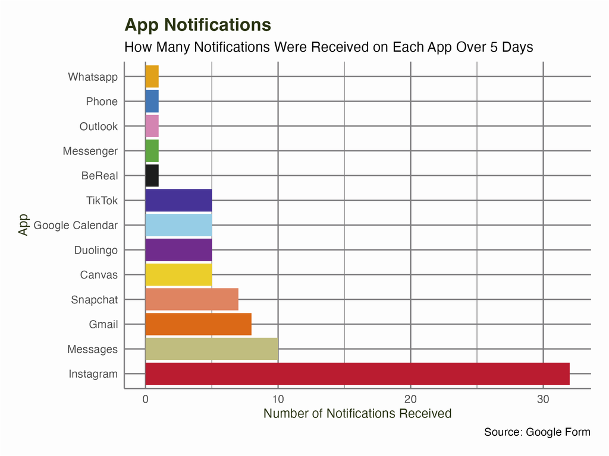

I get the most notifications from Instagram, at over 30 notifications in five days. The apps I get the least notifications from are Whatsapp, Outlook, Phone, Messenger, and BeReal, at only one each for the five days.

## What’s The Point?

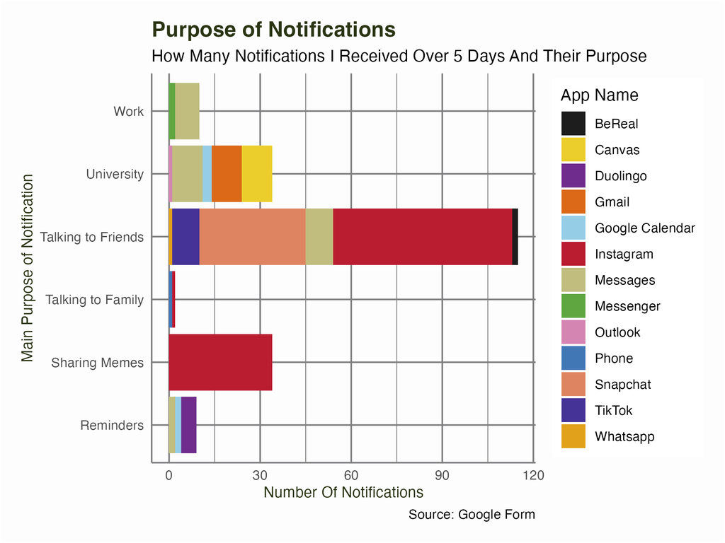

My Purpose Graph

I get notifications for a variety of reasons, but the most common notification I get is talking with friends. This happens on Instagram and Snapchat mostly. I get the least notifications talking to family, this is because I usually see them once a week, so don’t need to constantly keep in contact.

## Who, What… When?

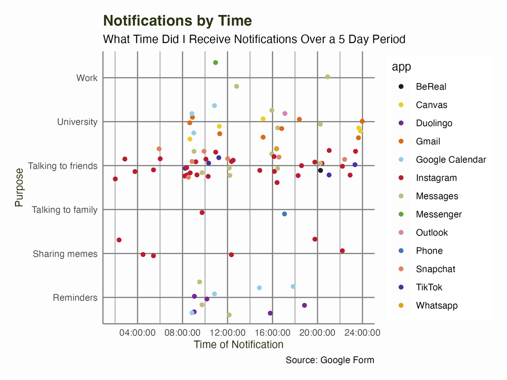

My Time Graph

I get notifications throughout most of the day, even at night (as some of my friends live overseas in different timezones). I get a large number of notifications just when I’m getting up, at around 8.30am - 9.00am. Then there are another group of notifications that typically happen around 4.00pm.

## Sorry For The Delayed Reply…

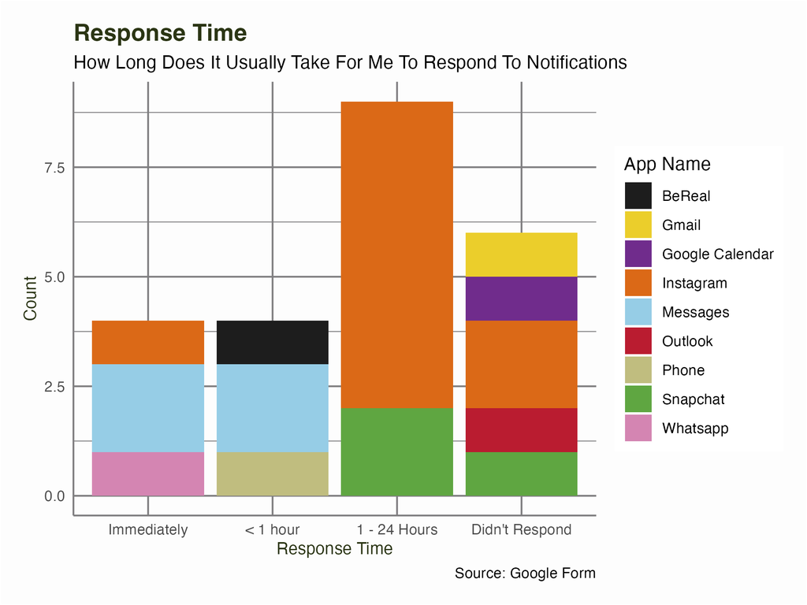

My Response Graph